# BeatTS_GlobalKriging

August 27, 2015

The beat and district numbers in the data were re-assigned by finding in which new beat/district polygon the point falls and then label that beat/district number. Therefore all violent crime beat and district records have a unified reference which is the new CPD beat/district map.

The evaluation date starts from 2014-08-01 and ends on 2014-08-04. The time series training uses 12-year data before the corresponding testing date.

The time series models were applied to each beat. The residuals later would be used to get empirical variogram.

Variogram models were estimated from recent two-year beat-level residual data. All the beats over the entire city were paired up to get a global empirical variogram. We use only two year data and consider the time intervals up to 14 days to relieve computation burden.

Three commonly used spatio-temporal covariance models are namely,

the metric model: $C_{st}(h_s,h_t) = C(a^2|h_s|^2+b^2h_t^2)$ the separable (product) model: $C_{st}(h_s,h_t) = C_s(h_s)C_t(h_t)$ the product-sum model: $C_{st}(h_s,h_t) = k_1C_s(h_s)C_t(h_t)+k_2C_s(h_s)+k_3C_t(h_t)$

Utilizing the relation $\gamma(h)=C(0)-C(h)$, we can write these covariance expressions in terms of variogram, for example,

the separable model: $\gamma_{st}(h_s,h_t) = C_t(0)\gamma_s(h_s)+C_s(0)\gamma_t(h_t)-\gamma_s(h_s)\gamma_t(h_t)$ the product-sum model: $\gamma_{st}(h_s,h_t) = [k_2+k_1C_t(0)]\gamma_s(h_s)+[k_3+k_1C_s(0)]\gamma_t(h_t)-k_1\gamma_s(h_s)\gamma_t(h_t)$

where the parameter $k_1,k_2,k_3$ are defined as $k_1 = [C_s(0)+C_t(0)-C_{st}(0,0)]/C_s(0)C_t(0)$ $k_2 = [C_{st}(0,0)-C_t(0)]/C_s(0)$ $k_3 = [C_{st}(0,0)-C_s(0)]/C_t(0)$

and variogram models $\gamma(h)$ are of forms:

spherical model $\gamma(h) = \begin{cases} C_{0}[\frac{3h}{2a_0}-\frac{1}{2}(\frac{h}{a_0})^3], & h \leq a_0\\ C_{0}, & h > a_0 \end{cases}$ exponential model $\gamma(h) = C_{0}[1-\exp(-\frac{h}{a_0})]$ and Gaussian model $\gamma(h) = C_{0}[1-\exp(-\frac{h^2}{a_{0}^{2}})]$

Where $C_0$ is the nugget and $a_0$ is the range. In our experiment, we choose the product-sum model with the spherical model for both temporal and spatial terms.

One variogram and its fitting is shown below.

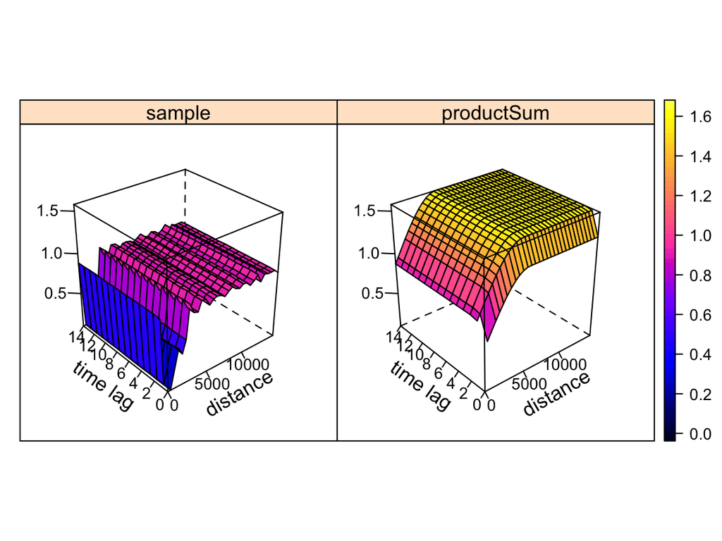

Here shows an example of time series predictions’ and residuals’ distribution (last evaluation example).

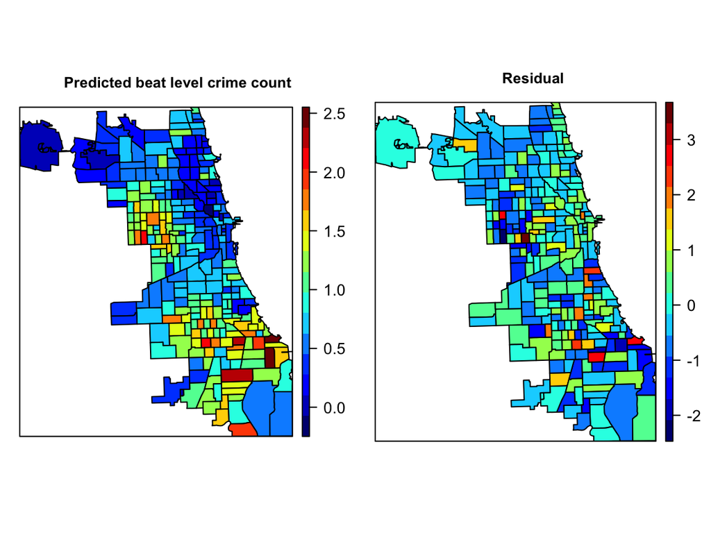

Here is the visualization of prediction results.

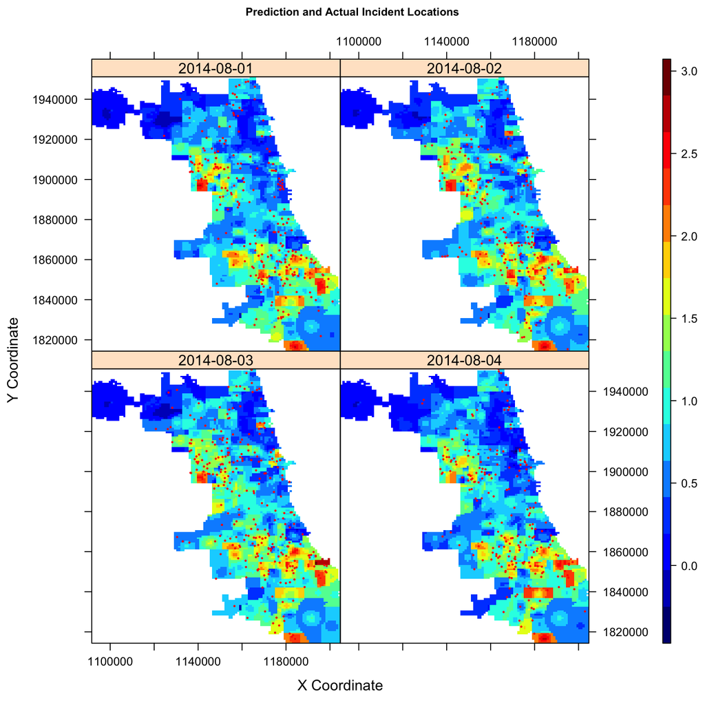

The evaluation is done through sensitivity(TPR)-like comparison between prediction model,long-term density and short-term density. To illustrate the idea, we demonstrate an example below the *sensitivity* plots: first selecting 10% highest pixels (threshold = 0.9 quantile of image histogram) then count how many actual crime incidents happened in these regions. And we do in this fashion for different threshold quantiles to get the *sensitivity* plot.

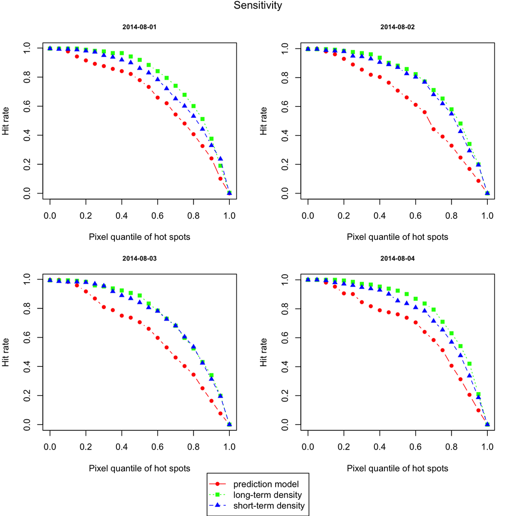

[figure not shown]

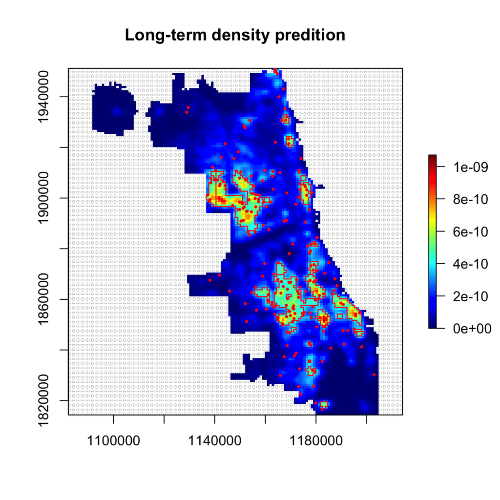

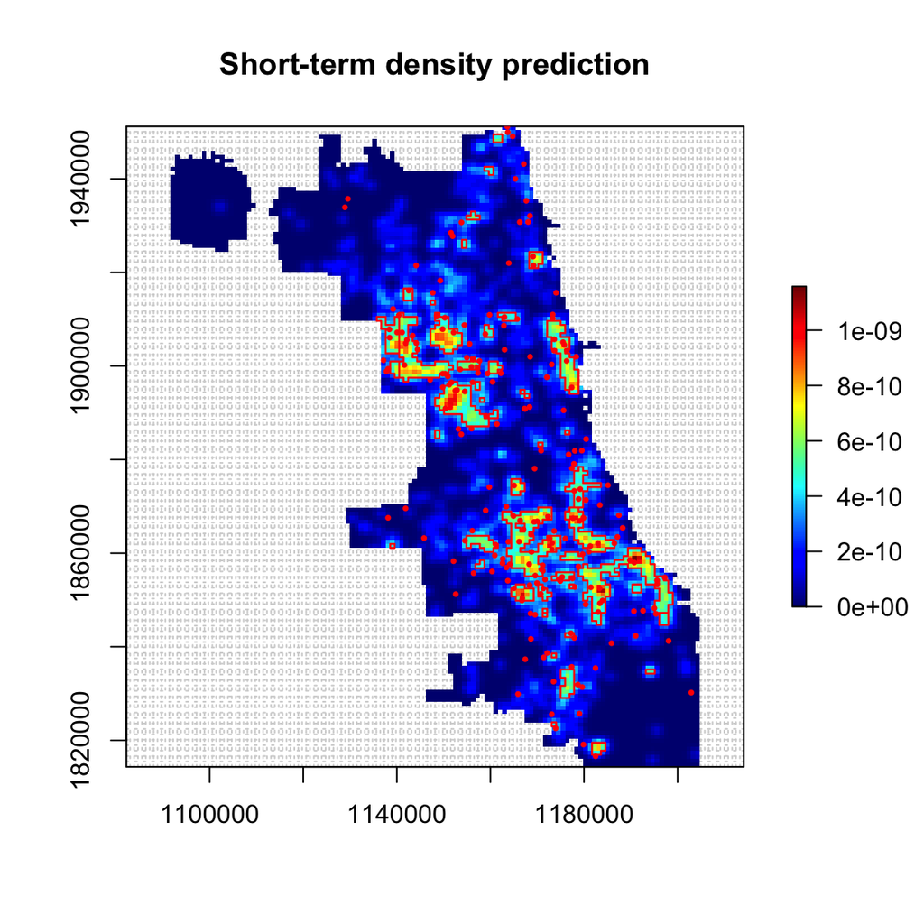